# Power analysis with Bayesian mixing models

CJ Brown

2017-07-28

`remixsiar` can be used to implement a type of broad-sense power analysis for Bayesian mixing models.

Here we demonstrate how it could be used to decide on a sample size for consumer isotope sampling.

```r
library(remixsiar)
```

## Simulating isotope data

Let’s create a simple mixing polygon, based on the work by Masello et al. on gulls. We will just specify means and SDs for each

```r
tracer_means <- c(-17, 12.75)
tracer_sds <- c(0.35, 1.1)
smeans <- cbind(cmean = c(-19.2, -15.72, -17.18), nmean = c(9.54, 11.24, 15.34))
ssds <- cbind(c(0.41, 1.02, 1.61), c(1.15, 1.64, 2.15))
snames <- c("Krill", "Mussels", "Shag_prey")
```

Now we can use `simmr_fitsim` to sample `n` samples from the consumer means and SDs and fit a `simmr` model using the source means and SDs.

```r
mod1 <- simmr_fitsims(n = 5, tracer_means = tracer_means,tracer_sds = tracer_sds,
      snames = snames, smeans = smeans, ssds = ssds, seed = 42)
```

`simmr_fitsims` stores both the input and output for simmr. Let’s plot the isospace plot (input) and the posterior diet contributions (output)

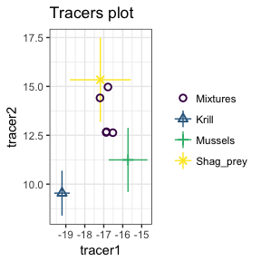

```r
plot(mod1$dat_in)
```

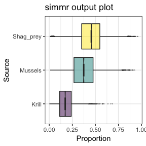

```r
plot(mod1$dat_out, type = "boxplot")
```

Calculating the information gain statistics is now straightforward:

```r
calckl(mod1)
```

```
## [1] 0.6698504 0.3711394 0.5929537
```

```r
calchell(mod1)
```

```
## [1] 0.41 0.27 0.33
```

Note that we are assuming that the default priors have been used here (which they have).

## Varying sample size

To do a power analysis, we would like to know how the information gain changes as we increase the number of consumer samples. We simply need to loop over `simmr_fitsims` and vary the input sample size. To do this, first create a data-frame of sample sizes and random seeds (so results are repeatable).

```r
nvals <- c(5, 10, 20, 40, 80)
seeds <- seq(10, 60, by = 10)
```

We will also specify the mcmc control parameters

```r
mcmc.control <-  list(iter = 10000, burn = 2000, thin = 10, n.chain = 2)
prior.control <- NULL
```

Note that you should use more iterations and chains, but we use just a few hear to speed simulation.

Now replicate every seed for every sample size and stick that dataframe together with the input to `simmr_fitsims`

```r
dfin <- expand.grid(n = nvals, seed = seeds)
df <- c(as.list(dfin),
list(tracer_means = list(tracer_means), tracer_sds = list(tracer_sds),
snames = list(snames), smeans = list(smeans), ssds = list(ssds),
mcmc.control = list(mcmc.control), prior.control = list(NULL)))
```

We can now loop over all sample sizes and randoms seeds using `pmap` from the `purrr` package, but you could also use a `for` loop to achieve the same effect

```r
library(purrr)
system.time(gulls_multirun <- pmap(df, simmr_fitsims))
```

```
##    user  system elapsed
##  56.378   0.110  56.759
```

Once that has fit (may take a while for larger datasets) we need to calculate the Hellinger distance and Kullback-Leibler divergences for each model fit, then stick the results back onto our dataframe of inputs:

```r
rout <- map(1:length(gulls_multirun), ~calchell(gulls_multirun[[.x]]))
routkl <- map(1:length(gulls_multirun), ~calckl(gulls_multirun[[.x]]))
rdf <- do.call(rbind, rout) %>% data.frame() %>%
  setNames(paste0('hd', snames)) %>%
  cbind(dfin)
rdf2 <- do.call(rbind, rout) %>% data.frame() %>%
  setNames(paste0('kl', snames)) %>%
  cbind(rdf)
```

Let’s plot the result now:

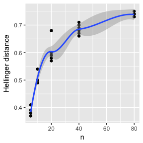

```r
library(ggplot2)

ggplot(rdf, aes(x = n, y = hdKrill)) + geom_point() +
    stat_smooth() + ylab("Hellinger distance")
```

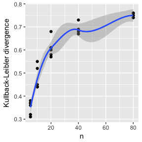

```r
ggplot(rdf2, aes(x = n, y = klMussels)) + geom_point() +
  stat_smooth() + ylab("Kullback-Leibler divergence")
```

So both information gain metrics increase with sample size, but there is not much benefit to 80 consumer samples over having only 40, whereas 5 samples gives us very weak inference compared to 20.